# 1.2. Measures of Dipsersion (Spread)

## Five-Number Summary

The Five-number summary, or 5-number summary for short can be used to describe the distribution of data samples for data with any distribution. The Five-number summary involves the calculation of 5 summary statistical quantities,namely:

- Median i.e., the middle value in the sample, also called the 50th percentile or the 2nd quartile.
- 1st Quartile i.e., The 25th percentile.
- 3rd Quartile i.e., The 75th percentile.
- Minimum: The smallest observation in the sample.
- Maximum: The largest observation in the sample.

```python
# generate a random data of 1000 values and calculate a 5-number summary
# Hint: Use rand from numpy.random package, do not forget to use seed if you wish to see same result everytime

from numpy import percentile
from numpy.random import seed
from numpy.random import rand

# seed random number generator
seed(1)

# generate data sample
data = rand(1000)

# calculate quartiles
quartiles = percentile(data, [25, 50, 75])

# calculate min/max
data_min, data_max = data.min(), data.max()

# display 5-number summary
print('Min: %.3f' % data_min)
print('Q1: %.3f' % quartiles[0])
print('Median: %.3f' % quartiles[1])
print('Q3: %.3f' % quartiles[2])
print('Max: %.3f' % data_max)
```

```
Min: 0.000
Q1: 0.252
Median: 0.508
Q3: 0.751
Max: 0.997
```

### Boxplot

In descriptive statistics, a box plot or boxplot is a method for graphically depicting groups of numerical data through their quartiles. Box plots may also have lines extending from the boxes (whiskers) indicating variability outside the upper and lower quartiles, hence the terms box-and-whisker plot and box-and-whisker diagram.

A boxplot is a standardized way of displaying the distribution of data based on a five number summary. It can tell you about your outliers and what their values are. It can also tell you if your data is symmetrical, how tightly your data is grouped, and if and how your data is skewed.

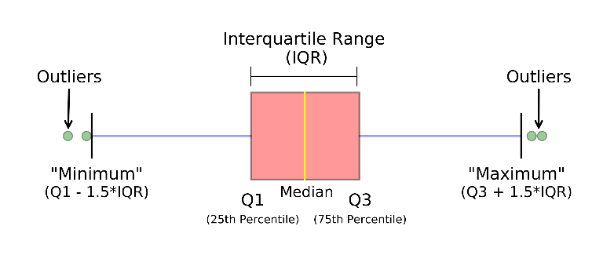

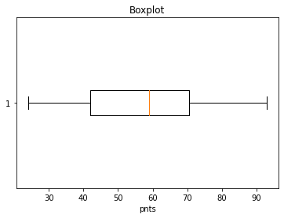

```python
import matplotlib.pyplot as plt

plt.boxplot(pnts,vert = False)
plt.title('Boxplot')
plt.xlabel('pnts')
plt.show()
```

Recall the first question asked in this section where the disccusion of measure of spread started. You can clearly observe the difference in spread of the data points among the two sets.

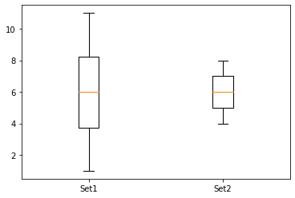

```python
set1 = [1, 2, 3, 4, 5, 6, 6, 7, 8, 9, 10, 11]
set2 = [4, 5, 5, 5, 6, 6, 6, 6, 7, 7, 7, 8]

plt.boxplot([set1,set2])
plt.xticks(ticks = [1,2], labels=('Set1', 'Set2'))
plt.show()
```

Let's have a quick look to analyse the spread when data is stored in a dataframe.

```python
#import pandas and numpy

import pandas as pd
import numpy as np
```

```python
# Let's build a data set

df = pd.DataFrame([
 { 'name': 'Smushface', 'salary': 12000,'degree': 'BS'} ,
 { 'name': 'Jen', 'salary': 25000,'degree': 'BS' },
 { 'name': 'James', 'salary': 55000,'degree': 'MS' },
 { 'name': 'Ross', 'salary': 35000,'degree': 'MS' },
 { 'name': 'Tyler', 'salary': 25000,'degree': 'BS' },
 { 'name': 'Jacques', 'salary': 15000,'degree': 'BS' },
 { 'name': 'Gates', 'salary': 100000,'degree': 'PhD' },
 { 'name': 'Peter', 'salary': 30000,'degree': 'MS' },
 { 'name': 'Adam', 'salary': 25000,'degree': 'MS' },
 { 'name': 'Brian', 'salary': 20000,'degree': 'BS' }
])
df
```

|  | name | salary | degree |
| --- | --- | --- | --- |
| 0 | Smushface | 12000 | BS |
| 1 | Jen | 25000 | BS |
| 2 | James | 55000 | MS |
| 3 | Ross | 35000 | MS |
| 4 | Tyler | 25000 | BS |
| 5 | Jacques | 15000 | BS |
| 6 | Gates | 100000 | PhD |
| 7 | Peter | 30000 | MS |
| 8 | Adam | 25000 | MS |
| 9 | Brian | 20000 | BS |

```python
#find Range

max_sal = df['salary'].max()
min_sal = df['salary'].min()

range_sal = max_sal - min_sal
print('Range:',range_sal)
```

```
Range: 88000
```

```python
# calculating IQR requires calculating 1st and 3rd quartiles.

Q1 = df['salary'].quantile(0.25)
Q3 = df['salary'].quantile(0.75)

IQR = Q3 - Q1
print('IQR:',IQR)
```

```
IQR: 12500.0
```

```python
# Absolute mean deviation

MAD = df['salary'].mad()  # mad() is mean absolute deviation function
print('Mean Absolute Deviation:',MAD)
```

```
Mean Absolute Deviation: 17480.0
```

```python
#Calculating variance

var_sal = df['salary'].var()
print('Variance:',var_sal)
```

```
Variance: 677511111.1111112
```

```python
#Calculating std. deviation

std_sal = df['salary'].std()
print('Standard Deviation,:',std_sal)
```

```
Standard Deviation,: 26029.04360730742
```

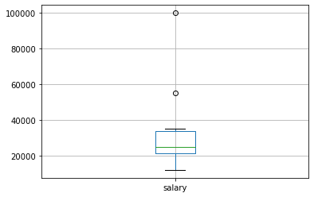

```python
#plot Boxplot for 'salary' column in the dataframe

df.boxplot(column='salary')
```

You can see that the salary of 'Gates' is well detetcted as an outlier by the box-plot.

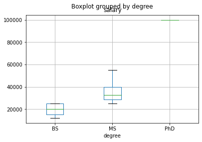

```python
#plot Boxplot for 'salary' for various categories in 'degree' column in the dataframe

df.boxplot(column='salary', by = 'degree')
```

`describe()` is a one shot command to gain most of the descriptive stats related to the dataset.

```python
df.describe()
```

|  | salary |
| --- | --- |
| count | 10.000000 |
| mean | 34200.000000 |
| std | 26029.043607 |
| min | 12000.000000 |
| 25% | 21250.000000 |
| 50% | 25000.000000 |
| 75% | 33750.000000 |
| max | 100000.000000 |

Notice that only columns having numeric values are displayed by `describe()`.

**Que:** The following data are numbers of passengers on flights of Delta Air Lines between San Francisco and Seattle over 33 days in April and early May.

128, 121, 134, 136, 136, 118, 123, 109, 120, 116, 125, 128, 121, 129, 130, 131, 127, 119, 114, 134, 110, 136, 134, 125, 128, 123, 128, 133, 132, 136, 134, 129, 132

- Find the median, the first and third quartile and hence find IQR.
- What would you like to say about the spread (dispersion) of dataset.
- Plot a box plot to display 5-summary points graphically.
- Comment on the symmetry (skweness) of dataset.